# Hackathon 2023 Task 2: Code

Group: hack Members: Armande Aboudrar-Meda, Giorgio Coppola, Varvara Ilyina, Giulia Petrilli, Luca Vellage

December 29, 2023

## Setup

```r
## load packages
pacman::p_load(tidyverse, leaflet, tigris, sf, haven, RColorBrewer)

## load survey data
data_survey <- read_rds("./survey/meof_usa_survey_df.RDS")

## load tracking data
data_tracking <- readr::read_rds("./tracking/meof_usa_web_df.RDS")
```

## Data operationalization

At first glance, the MEOF survey data seem quite large and difficult to work with. Navigating the data by hand felt like a tedious task, but after narrowing down our topic of interest, we were able to pick out some variables of interest. Further exploration of the data led us to limit our time frame to the fourth wave.

The comparison of certain variable outputs yielded fruitful results. The most interesting variables for our analysis were the self-evaluated threat perceptions on various items, determined by the range of `threat_` variables.

### Self-perception of various threats

As a first step, we plotted histograms of each of the `threat_` variables present in the survey data. Comparisons are done between threat perceptions of terrorist attacks, Russia’s interference in US elections, a nuclear attack from North Korea, Iran’s development of nuclear weapons, jobs being taken by undocumented immigrants and the loss of jobs to China.

The exact shares of respondents per category can be deduced from the plot below. The responses range from (1) “Extremely concerned” to (4) “Not at all concerned”. Most distributions depict a either a large share of respondents in the middle two categories (showing potential indecisiveness) or a strong preference towards one category.

```r
## vector with threat variables
vars_threat <- data_survey %>%
  select(starts_with("threat_")) %>%
  names()

## threat variable endings
type_threat <- vars_threat %>%
  str_extract("_[^_]+$")


## vector with count variables
count_threat <- paste0("count", type_threat)


## vector with share variables
share_threat <- paste0("share", type_threat)


## vector with ggorder variables
ggorder_threat <- paste0("ggorder", type_threat)


## clean df for loop
df_loop <- data_survey %>%
  filter(wave == 4) %>%
  select(personid, starts_with("threat_"))


## loop across threat variables
for (i in seq_along(vars_threat)) {

  df_tmp <- df_loop %>%
    select(personid, vars_threat[i]) %>%
    rename(threat_var = 2) %>%
    group_by(threat_var) %>%
    mutate(threat_var = as.numeric(threat_var),
           count = n()) %>%
    ungroup() %>%
    group_by() %>%
    mutate(share = count / length(threat_var) * 100,
           share = round(share, 1)) %>%
    ungroup() %>%
    rename_with(~paste0("count", type_threat[i]), count) %>%
    rename_with(~paste0("share", type_threat[i]), share) %>%
    rename_with(~paste0("ggorder", type_threat[i]), threat_var)

  df_loop <- left_join(df_loop, df_tmp, by = "personid")

}


## generate labels
df_loop <- df_loop %>%
  mutate(across(starts_with("threat_"), haven::as_factor)) %>%
  mutate_at(vars(starts_with("threat_")),
            ~ str_wrap(., width = 12)) %>%
  select(-personid) %>%
  unique()


## generate caption
caption_dat <- "Data from the Media Exposure and Opinion Formation (MEOF) survey, \n conducted between October 30 and November 6, 2018 (4th survey wave) in the United States"


## prepare theme for plot
stand_theme <- theme_classic() +
  theme(plot.title = element_text(size = 10),
        axis.title.y = element_text(vjust = 1, size = 9),
        axis.text.y = element_text(size = 8),
        axis.text.x = element_text(angle = 45, hjust = 1, size = 8),
        plot.subtitle = element_text(size = 21),
        plot.caption = element_text(size = 6),
        legend.title = element_blank())
```

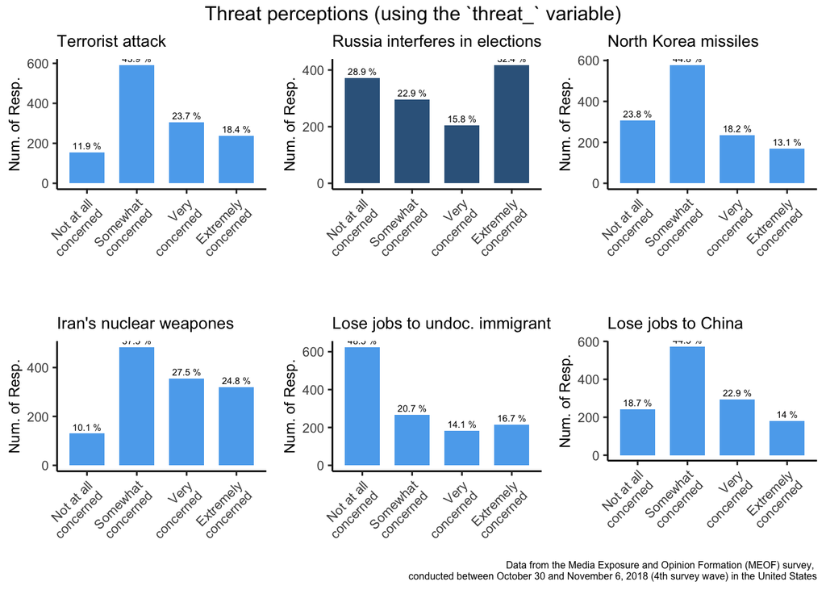

```r
## arrange plots
gridExtra::grid.arrange(p_terrorist, p_russia, p_northkorea, p_iran, p_undocumented, p_china,
                        nrow = 2,
                        top = "Threat perceptions (using the `threat_` variable)")
```

### Self-perception of a threat from Russia

Nonetheless, there is an evident polarization in the threat evaluation of Russia interfering in the US midterm elections. Compared to the other five variables, the distribution of the self-evaluated threat perception from Russia is equally split between respondents. For this reason, we focus on the specific threat variable about Russia, in relation to the type of news consumed by US citizens.

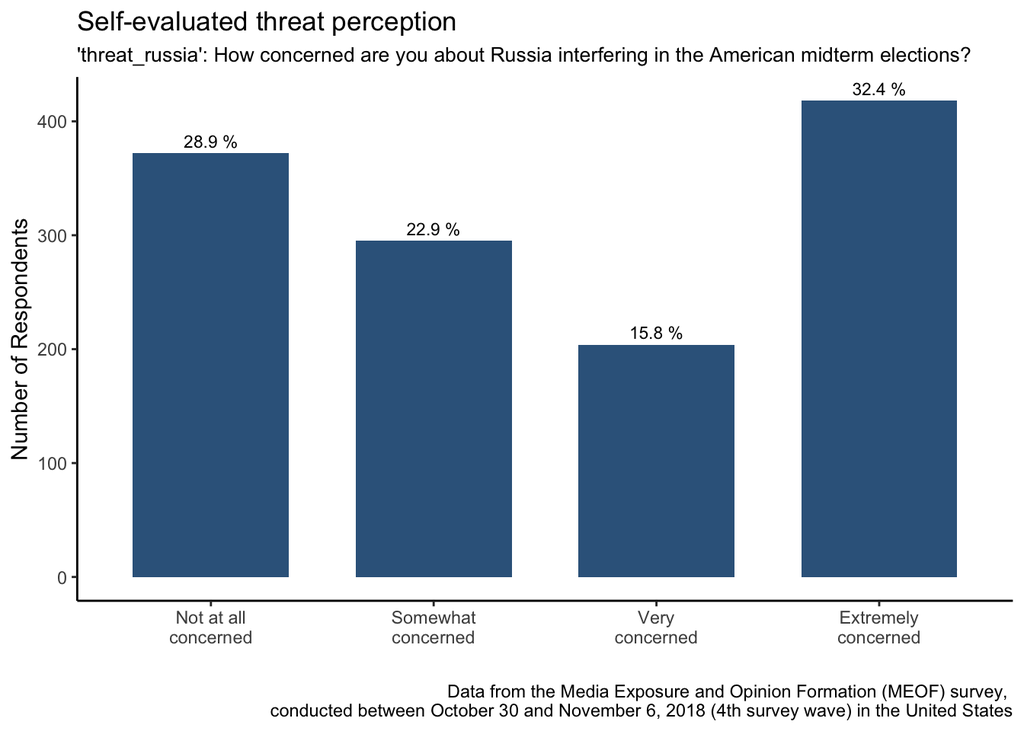

```r
## plot
p_russia <- df_loop %>%
  select(ends_with("_russia")) %>%
  unique() %>%
  ggplot(.,  aes(reorder(threat_russia, -ggorder_russia), count_russia)) +
  geom_bar(stat = "identity", position = "stack", width = 0.7, fill = "steelblue4") +
  scale_y_continuous(limits = c(0, max(df_loop$count_russia)),
                     breaks = seq(0, max(df_loop$count_russia + 150), by = 100)) +
    labs(title = "Self-evaluated threat perception",
         subtitle = "'threat_russia': How concerned are you about Russia interfering in the American midterm elections?",
         x = "",
         y = "Number of Respondents",
         caption = caption_dat) +
  geom_text(aes(threat_russia, count_russia, label = str_c(share_russia, " %")),
                position = position_dodge(0.9),
                vjust = -0.5,
                size = 3) +
  theme_classic() +
  theme(plot.subtitle = element_text(size = 10))


# output plot
print(p_russia)
```

## Analysis

In the following chunks, we aimed at studying the different patterns of news online consumption based on the variable “threat_russia”, defined as “Russia interfering in the American midterm elections”. The respondents to the survey had 4 choice of answers : extremely concerned, very concerned, somewhat concerned, or not at all concerned, and there were also the possibilities for the question to be skipped or not asked. We chose in our analysis to keep our attention on “extremely concerned” and “not at all concerned” and to use the variable as a dummy or an operalization of seeing or not Russia as a threat.

To study the different patterns of consumption of information between the respondents seeing Russia as a threat or not, we first merged the two datasets and we then found a strategy to select the domains in our dataset that could be considered as online news consumption. We did our choice of online news consumotion based on an article (referenced in the report) which helped us to choose our domains and to put them in different political categories. We finally studied and compared the difference in the use of these selected online news between the two groups.

```r
### data load and cleaning
# web data
web_data_slim <- data_tracking |>
  select(personid, domain, duration)

# survey data
survey_data_slim <- data_survey |>
  filter(wave == 4) |>
  select(personid, gender, birthyr, race, educ, employ, faminc_new, religpew, presvote16post, threat_russia,  knowevents4_russiaint_TRUE,  feeling_russia)

### merge data and clean
# inner join to keep only respondents who provided tracking data and answered survey
join_survey_data <- survey_data_slim |>
  inner_join(web_data_slim, join_by(personid))

# filtered join data and dummy
join_survey_data_threat <- join_survey_data |>
  filter(threat_russia == 4 | threat_russia == 1) |>
  mutate(dummy_threat = ifelse(threat_russia == 4, 0, 1)) |>
  filter(duration >= 30) # filter out web search that are less than 30 sec

# check the counts for each dummy
threat_counts <- join_survey_data_threat %>%
  group_by(dummy_threat) %>%
  summarize(count = n())

# what's the top 10 domain?
top_domains <- join_survey_data_threat  |>
  group_by(domain) |>
  summarise(count = n()) |>
  arrange(desc(count)) |>
  filter(row_number() <= 10) |>
  pull(domain)

# what are the unique domains at this stage?
unique_domains_filt <- join_survey_data_threat |>
  pull(domain) |>
  unique() |>
  as_tibble()
```

### Conceptualization

Conceptualization based on [AllSides Media Bias Chart, 2023]{https://www.allsides.com/media-bias/media-bias-chart}.

```r
# creation of our categories based on the article referenced in the report
 left_news_keywords <- c("alternet", "theatlantic", "democracynow", "dailybeast",
                         "huffpost", "theintercept", "jacobin", "motherjohns",
                         "msnbc", "newyorker", "nytimes", "thenation", "vox", "slate")

 leanleft_news_keywords <- c("abcnews", "apnews", "cbsnews", "cnn", "axios", "bloomberg",
                             "theguardian", "insider", "npr", "politico", "propublica",
                            "time", "washingtonpost", "usatoday", "news.yahoo")

center_news_keywords <- c("bbc", "csmonitor", "forbes", "marketwatch", "newsnationnow",
                          "newsweek", "reuters", "realclearpolitics", "thehill", "wsj")

leanright_news_keywords <- c("thedispatch", "epochtimes", "foxbusiness", "nationalreview",
                             "nypost", "reason", "washingtonexaminer", "washingtontimes")

right_news_keywords <- c("theamericanconservative", "spectator", "breitbart", "theblaze",
                         "cbn", "dailycaller", "dailymail", "dailywire", "thepostmillennial",
                         "foxnews", "thefederalist", "ijr", "nationalreview", "nypost",
                         "newsmax", "oann", "freebeacon")

join_survey_data_threat_cat <- join_survey_data_threat %>%
  mutate(category = case_when(
    grepl(paste0(paste(left_news_keywords, collapse = "|")), domain, ignore.case = TRUE) ~ "left_news",
    grepl(paste0(paste(leanleft_news_keywords, collapse = "|")), domain, ignore.case = TRUE) ~ "leanleft_news",
    grepl(paste0(paste(center_news_keywords, collapse = "|")), domain, ignore.case = TRUE) ~ "center_news",
    grepl(paste0(paste(leanright_news_keywords, collapse = "|")), domain, ignore.case = TRUE) ~ "leanright_news",
    grepl(paste0(paste(right_news_keywords, collapse = "|")), domain, ignore.case = TRUE) ~ "right_news",
    TRUE ~ NA_character_
  ))
```

```r
left_news <- join_survey_data_threat_cat |>
  filter(category == "left_news") |>
  select(domain) |>
  unique()

leanleft_news <- join_survey_data_threat_cat  |>
  filter(category == "leanleft_news")  |>
  select(domain) |>
  unique()

center_news <- join_survey_data_threat_cat|>
  filter(category == "center_news") |>
  select(domain) |>
  unique()

leanright_news <- join_survey_data_threat_cat |>
  filter(category == "leanright_news") |>
  select(domain) |>
  unique()

right_news <- join_survey_data_threat_cat |>
  filter(category == "right_news") |>
  select(domain) |>
  unique()

# We checked the domains grouped by the category, and we found 6 domains that are not news wesites: invox community, google translate, question pro, business insider, transformation insider and time.rmprod.zone. We want to delete them.

# domains to change
domains_to_change <- c("univoxcommunity.com", "translate.google.com", "questionpro.com", "businessinsider.com", "transformationinsider.com", "time.rmprod.zone")

join_survey_data_threat_cat_new <- join_survey_data_threat_cat %>%
  mutate(category = ifelse(domain %in% domains_to_change, NA, category))


# We need to filter our dataset only keeping the relevant web activities.
combined_news <- bind_rows(
  left_news,
  leanleft_news,
  center_news,
  leanright_news,
  right_news
)

join_survey_data_threat_cat_filt <- join_survey_data_threat_cat_new %>%
  filter(domain %in% combined_news$domain)
```

### Tables

```r
# We now want to do a table to compare, within our online news, the 20 most visited online news websites by the perception of Russia as a threat
domain_visits <- join_survey_data_threat_cat_filt %>%
  filter(!is.na(category)) %>%
  group_by(dummy_threat, domain, category) %>%
  summarise(visit_count = n(), .groups = 'drop') %>%
  arrange(dummy_threat, desc(visit_count))

top_no_threat <- domain_visits %>%
  filter(dummy_threat == 0) %>%
  slice_head(n = 20)

top_threat <- domain_visits %>%
  filter(dummy_threat == 1) %>%
  slice_head(n = 20)

# Create and save the table for dummy_threat == 0
table_no_threat <- knitr::kable(
  top_no_threat,
  format = "markdown",
  caption = "Top 20 Domains with No Threat Perceived"
)

# Creating a table for top_threat
table_threat <- knitr::kable(
  top_threat,
  format = "markdown",
  caption = "Top 20 Domains with Threat Perceived"
)

# Display the tables
table_no_threat
```

Top 20 Domains with No Threat Perceived

| dummy_threat | domain | category | visit_count |
| --- | --- | --- | --- |
| 0 | foxnews.com | right_news | 5094 |
| 0 | dailymail.co.uk | right_news | 633 |
| 0 | a57.foxnews.com | right_news | 595 |
| 0 | projects.propublica.org | leanleft_news | 489 |
| 0 | video.foxnews.com | right_news | 344 |
| 0 | adtag.primetime.adobe.com | leanleft_news | 287 |
| 0 | t.dailymail.co.uk | right_news | 276 |
| 0 | bea4.cnn.com | leanleft_news | 197 |
| 0 | cnn.com | leanleft_news | 165 |
| 0 | nytimes.com | left_news | 155 |
| 0 | insider.foxnews.com | leanleft_news | 151 |
| 0 | i.dailymail.co.uk | right_news | 139 |
| 0 | breitbart.com | right_news | 135 |
| 0 | foxbusiness.com | leanright_news | 131 |
| 0 | theblaze.com | right_news | 120 |
| 0 | ted.dailymail.co.uk | right_news | 93 |
| 0 | media2.foxnews.com | right_news | 88 |
| 0 | usatoday.com | leanleft_news | 82 |
| 0 | cookie.brealtime.com | leanleft_news | 80 |
| 0 | video.dailymail.co.uk | right_news | 76 |

```r
table_threat
```

Top 20 Domains with Threat Perceived

| dummy_threat | domain | category | visit_count |
| --- | --- | --- | --- |
| 1 | foxnews.com | right_news | 4745 |
| 1 | dev-cronkite.api.cnnlabs.io | leanleft_news | 1558 |
| 1 | cnn.com | leanleft_news | 1420 |
| 1 | nytimes.com | left_news | 1383 |
| 1 | washingtonpost.com | leanleft_news | 1091 |
| 1 | projects.propublica.org | leanleft_news | 629 |
| 1 | et.nytimes.com | left_news | 605 |
| 1 | thehill.com | center_news | 597 |
| 1 | theguardian.com | leanleft_news | 507 |
| 1 | usatoday.com | leanleft_news | 383 |
| 1 | politico.com | leanleft_news | 360 |
| 1 | bbc.com | center_news | 203 |
| 1 | adtag.primetime.adobe.com | leanleft_news | 191 |
| 1 | vox.com | left_news | 170 |
| 1 | thedailybeast.com | left_news | 162 |
| 1 | video.foxnews.com | right_news | 157 |
| 1 | a57.foxnews.com | right_news | 129 |
| 1 | slate.com | left_news | 127 |
| 1 | cookie.brealtime.com | leanleft_news | 96 |
| 1 | enewspaper.latimes.com | leanleft_news | 96 |

```r
#We first do a table of the difference of mean duration soent on the domains between the group which does`t consider Russia as a threat and the group which considers Russia as a threat
no_threat_perceived <- join_survey_data_threat_cat_filt %>%
  filter(dummy_threat == 0) %>%
  group_by(category) %>%
  summarise(no_threat_perceived = mean(duration, na.rm = TRUE))

threat_perceived <- join_survey_data_threat_cat_filt %>%
  filter(dummy_threat == 1) %>%
  group_by(category) %>%
  summarise(threat_perceived = mean(duration, na.rm = TRUE))

dummy_threat_0 <- join_survey_data_threat_cat_filt %>%
  filter(dummy_threat == 0) %>%
  group_by(category) %>%
  summarise(no_threat_perceived = mean(duration))

dummy_threat_1 <- join_survey_data_threat_cat_filt %>%
  filter(dummy_threat == 1) %>%
  group_by(category) %>%
  summarise(threat_perceived = mean(duration))

comparison_mean <- merge(no_threat_perceived, threat_perceived, by = "category", all = TRUE)
mean_duration <- comparison_mean

#We put the results of mean duration we have under the shape of a table
table_mean <- knitr::kable(
  mean_duration,
  format = "markdown",
  col.names = c("Category", "No Threat Perceived", "Threat Perceived"),
  align = "lcc",
  caption = "Mean Duration of use of online news by Category and Threat Perception"
)

writeLines(table_mean, "table.txt")

table_mean
```

Mean Duration of use of online news by Category and Threat Perception

| Category | No Threat Perceived | Threat Perceived |
| --- | --- | --- |
| center_news | 109.3451 | 189.3205 |
| leanleft_news | 137.9480 | 165.3257 |
| leanright_news | 110.2075 | 245.4195 |
| left_news | 161.8132 | 331.5003 |
| right_news | 132.2652 | 222.7215 |
| NA | 214.8404 | 248.1356 |

```r
#We now do the same thing for the variable counting the number of visits instead of the mean duration, that we once again compare between no threat perceived and threat oerceived
visit_count <- join_survey_data_threat_cat_filt %>%
  group_by(category, dummy_threat) %>%
  summarise(visit_count = n(), .groups = "drop")

visit_count_comparison <- visit_count %>%
  pivot_wider(names_from = dummy_threat, values_from = visit_count) %>%
  rename(`No Threat Perceived` = `0`, `High Threat Perceived` = `1`) %>%
  select(category, `No Threat Perceived`, `High Threat Perceived`) %>%
  arrange(category)

table_count <- knitr::kable(
  visit_count_comparison,
  format = "markdown",
  col.names = c("Category", "No Threat Perceived", "Threat Perceived"),
  align = "lcc",
  caption = "Mean Duration by Category and Threat Perception"
)

writeLines(table_count, "table.txt")

table_count
```

| Category | No Threat Perceived | Threat Perceived |
| --- | --- | --- |
| center_news | 452 | 1329 |
| leanleft_news | 2597 | 8081 |
| leanright_news | 424 | 174 |
| left_news | 423 | 3374 |
| right_news | 8179 | 5411 |
| NA | 10322 | 17516 |

### Plot

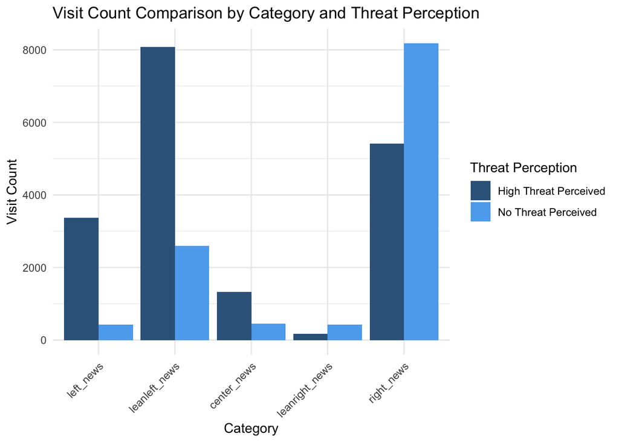

```r
long_format <-  visit_count_comparison |>
  pivot_longer(cols = c(`No Threat Perceived`, `High Threat Perceived`),
               names_to = "High Threat Perceived", values_to = "Count") |>
   filter(!is.na(category))

long_format <- long_format |>
  mutate(ggorder = case_when(
  category == "left_news" ~ 1,
  category == "leanleft_news" ~ 2,
  category == "center_news" ~ 3,
  category == "leanright_news" ~ 4,
  category == "right_news" ~ 5,
  TRUE ~ NA_real_))

# We create an histogram showing the visit count comparison by category and threat perception
barplot <- ggplot(long_format, aes(x = reorder(category, ggorder), y = Count, fill = `High Threat Perceived`)) +
  geom_bar(stat = "identity", position = "dodge") +
  scale_fill_manual(values = c("No Threat Perceived" = "steelblue2", "High Threat Perceived" = "steelblue4")) + # Custom colors
  theme_minimal() +
  labs(title = "Visit Count Comparison by Category and Threat Perception",
       x = "Category",
       y = "Visit Count",
       fill = "Threat Perception") +
  theme(axis.text.x = element_text(angle = 45, hjust = 1))

barplot
```